# Homework week 6 day 2

```r
library(prob)
library(tidyverse)
library(janitor)
library(skimr)
library(e1071)
```

```r
library(ggplot2)
```

## 1.1 Load and investigate data

```r
mobile_phone_data <- read_csv("data/20190928-items.csv") %>%
  clean_names()
```

### Check if every row represents a different title of phone

They do not - there are seven more observations than there are types of phone

```r
# Number of observations
mobile_phone_data %>%
  nrow()
```

```
## [1] 792
```

```r
# Number of unique titles
mobile_phone_data %>%
  distinct(title) %>%
  nrow()
```

```
## [1] 785
```

```r
# Number of unique "asin" codes
mobile_phone_data %>%
  distinct(asin) %>%
  nrow()
```

```
## [1] 792
```

### Identify the titles which appear more than once

For the purposes of this exercise I’m not going to investigate these any further - those with the same title have a different “asin” code, I’m just going to use **asin** as unique id

```r
# Titles which are not unique
mobile_phone_data %>%
  group_by(title) %>%
  summarise(number_of_records = n()) %>%
  arrange(number_of_records) %>%
  filter(number_of_records > 1)
```

| title | number_of_records |
| --- | --- |
| Apple iPhone 6, GSM Unlocked, 16GB - Space Gray (Renewed) | 2 |
| Google Pixel 2 XL 128GB Unlocked GSM/CDMA 4G LTE Octa-Core Phone w/ 12.2MP Camera - Just Black | 2 |
| Samsung Galaxy Note 8 SM-N950U 64GB for AT&T (Renewed) | 2 |
| Samsung Galaxy S7 Edge 32GB SM-G935T Unlocked GSM 4G LTE Android Smartphone (Renewed) | 2 |
| Samsung Galaxy S8 SM-G950U 64GB for AT&T (Renewed) | 2 |
| Samsung Galaxy S8 SM-G950U 64GB for T-Mobile (Renewed) | 3 |

## 1.2 Find the brand with the highest numbers of phones in the dataset.

```r
mobile_phone_data %>%
  group_by(brand) %>%
  summarise(number_of_phones = n()) %>%
  arrange(desc(number_of_phones))
```

| brand | number_of_phones |
| --- | --- |
| Samsung | 397 |
| Apple | 101 |
| Motorola | 100 |
| Nokia | 49 |
| HUAWEI | 36 |
| Google | 33 |
| Sony | 29 |
| Xiaomi | 27 |
| ASUS | 13 |
| OnePlus | 7 |

## 1.3 For your top brand, plot the distribution of phone ratings as a probability density, overlaying a fitted normal distribution. Do you think the normal distribution provides a good model of these ratings?

- Normal distribution looks like a reasonable match for the data, although:
  - there are outliers
  - the peak of the normal distribution is to the left of the peak shown in the data

```r
# Get mean & sd
samsung_stats <- mobile_phone_data %>%
  filter(brand == "Samsung") %>%
  summarise(
    num = n(),
    mean = mean(rating),
    sd = sd(rating)
  )
```

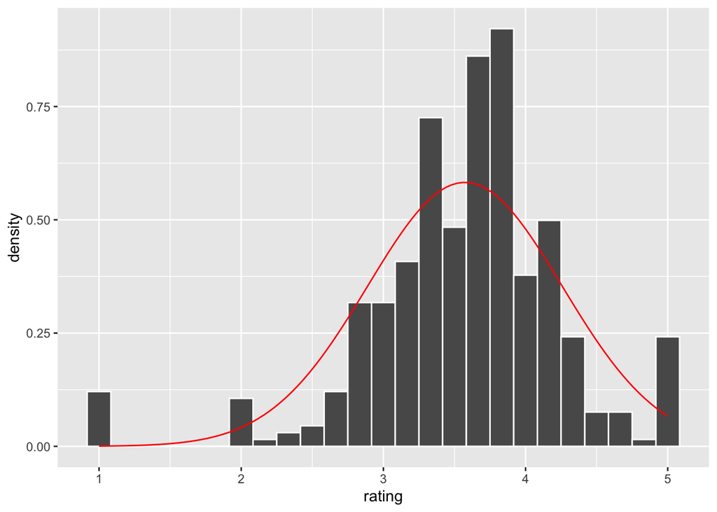

```r
# Plot the data
mobile_phone_data %>%
  filter(brand == "Samsung") %>%
  ggplot() +
  aes(x = rating) +
  geom_histogram(aes(y = ..density..), col = "white", bins = 25)  +
  stat_function(
    fun = dnorm,
    args = list(
      mean = samsung_stats$mean,
      sd = samsung_stats$sd
    ),
    col = "red"
  )
```

## 1.4 We can be more quantitative in comparing the distribution of top brand ratings with a normal distribution.

You calculated the mean() and sd() of your distribution in an earlier question. Use these values to calculate the proportions of ratings within one-, two- and three standard deviations of the mean. Compare these proportions with those you expect for a normal distribution.

```r
# Add z-scores
samsung_ratings_scaled <- mobile_phone_data %>%
  filter(brand == "Samsung") %>%
  mutate(z_rating = scale(rating))
```

```r
# Check for outliers - sd more than 3
samsung_ratings_scaled %>%
  filter(!between(z_rating, left = -3, right = 3))
```

| asin | brand | title | url | image | rating | review_url | total_reviews | prices | z_rating |
| --- | --- | --- | --- | --- | --- | --- | --- | --- | --- |
| B00R3R6W3W | Samsung | Samsung Convoy 3 Non-Camera, Gray (Verizon Wireless) | https://www.amazon.com/Samsung-Convoy-Non-Camera-Verizon-Wireless/dp/B00R3R6W3W | https://m.media-amazon.com/images/I/81iGOVN07rL._AC_UY218_SEARCH213888_FMwebp_QL75_.jpg | 1 | https://www.amazon.com/product-reviews/B00R3R6W3W | 2 | NA | -3.757816 |
| B01HQTL47A | Samsung | Samsung G920A Galaxy S6 32GB, Black Saphire (Renewed) | https://www.amazon.com/Samsung-G920A-Galaxy-Saphire-Renewed/dp/B01HQTL47A | https://m.media-amazon.com/images/I/31prNuzjoCL._AC_UY218_SEARCH213888_FMwebp_QL75_.jpg | 1 | https://www.amazon.com/product-reviews/B01HQTL47A | 2 | $135.98 | -3.757816 |
| B079TZ8NKG | Samsung | Samsung Galaxy S6 Edge G925T 64GB Gold Platinum - T-Mobile | https://www.amazon.com/Samsung-Galaxy-Edge-G925T-Platinum/dp/B079TZ8NKG | https://m.media-amazon.com/images/I/916OH+JvtDL._AC_UY218_SEARCH213888_FMwebp_QL75_.jpg | 1 | https://www.amazon.com/product-reviews/B079TZ8NKG | 1 | NA | -3.757816 |
| B07HC74RMG | Samsung | Samsung Galaxy S9 Enterprise Edition 64 GB Unlocked Phone With FREE Cellairis Phone Case & Screen Protector | https://www.amazon.com/Samsung-Enterprise-Unlocked-Cellairis-Protector/dp/B07HC74RMG | https://m.media-amazon.com/images/I/715LLCKpQEL._AC_UY218_SEARCH213888_FMwebp_QL75_.jpg | 1 | https://www.amazon.com/product-reviews/B07HC74RMG | 1 | $874.18 | -3.757816 |
| B07NLLFGTL | Samsung | Samsung Galaxy Note9 Smartphone 6.4" AT&T Android 512GB (Certified Refurbished) (Lilac Purple) | https://www.amazon.com/Samsung-Smartphone-Android-Certified-Refurbished/dp/B07NLLFGTL | https://m.media-amazon.com/images/I/51pdXCj33kL._AC_UY218_SEARCH213888_FMwebp_QL75_.jpg | 1 | https://www.amazon.com/product-reviews/B07NLLFGTL | 1 | $664.95 | -3.757816 |
| B07PC21HKM | Samsung | Samsung Galaxy S9+ SM-G9650 Dual Sim 128GB 6GB RAM 6.2" Super AMOLED Factory Unlocked - No Warranty (Sunrise Gold) (Renewed) | https://www.amazon.com/Samsung-Galaxy-SM-G9650-Factory-Unlocked/dp/B07PC21HKM | https://m.media-amazon.com/images/I/51jCNLU12JL._AC_UY218_SEARCH213888_FMwebp_QL75_.jpg | 1 | https://www.amazon.com/product-reviews/B07PC21HKM | 1 | $399.99 | -3.757816 |
| B07QG4FJ8Z | Samsung | Samsung Galaxy J2 Core 2018 Factory Unlocked 4G LTE (USA Latin Caribbean) Android Oreo SM-J260M Dual Sim 8MP 16GB (Gold) | https://www.amazon.com/Samsung-Factory-Unlocked-Caribbean-SM-J260M/dp/B07QG4FJ8Z | https://m.media-amazon.com/images/I/31f-b5A00bL._AC_UY218_SEARCH213888_FMwebp_QL75_.jpg | 1 | https://www.amazon.com/product-reviews/B07QG4FJ8Z | 1 | $103.74 | -3.757816 |
| B07SRD6SVX | Samsung | Samsung Galaxy S10e Verizon + GSM Unlocked 128GB Prism White (Renewed) | https://www.amazon.com/Samsung-Galaxy-Verizon-Unlocked-Renewed/dp/B07SRD6SVX | https://m.media-amazon.com/images/I/71+figFvKvL._AC_UY218_SEARCH213888_FMwebp_QL75_.jpg | 1 | https://www.amazon.com/product-reviews/B07SRD6SVX | 1 | $498.43 | -3.757816 |

```r
# Stuck on this - copied from  "hints", but I don't understand the logic

# Also don't know how to pipe all results into one output

samsung_ratings_scaled %>%
  filter(rating >= samsung_stats$mean - samsung_stats$sd) %>%
  filter(rating <= samsung_stats$mean + samsung_stats$sd) %>%
  summarise(prop_within_1sd = n() / nrow(samsung_ratings_scaled))
```

| prop_within_1sd |
| --- |
| 0.7934509 |

```r
# 2nd attempt - getting number of rows from z-scores table

nrow(samsung_ratings_scaled %>%
  filter(between(z_rating, left = -1, right = 1))) / nrow(samsung_ratings_scaled)
```

```
## [1] 0.7934509
```

```r
nrow(samsung_ratings_scaled %>%
  filter(between(z_rating, left = -2, right = 2))) / nrow(samsung_ratings_scaled)
```

```
## [1] 0.9193955
```

```r
nrow(samsung_ratings_scaled %>%
  filter(between(z_rating, left = -3, right = 3))) / nrow(samsung_ratings_scaled)
```

```
## [1] 0.9798489
```

```r
# Proportions in normal distribution

100 * (pnorm(q = 1) - pnorm(q = -1))
```

```
## [1] 68.26895
```

```r
100 * (pnorm(q = 2) - pnorm(q = -2))
```

```
## [1] 95.44997
```

```r
100 * (pnorm(q = 3) - pnorm(q = -3))
```

```
## [1] 99.73002
```